# Evaluation of a remote, internet-delivered version of the Trier Social Stress Test - ScienceDirect

## Outline

1. Highlights
2. Abstract
3. Keywords
4. 1. Introduction
5. 2. Material and methods
6. 3. Analytical approach
7. 4. Results
8. 5. Discussion
9. 6. Conclusions
10. Funder source
11. Appendix A. Supplementary data
12. References

## Figures (3)

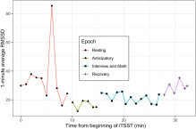

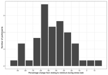

## Extras (1)

1. Descriptions of the Four Selah Pilot Study Interventions.

## [International Journal of Psychophysiology](https://www-sciencedirect-com.proxy.lib.duke.edu/science/journal/01678760)

[Volume 165](https://www-sciencedirect-com.proxy.lib.duke.edu/science/journal/01678760/165/supp/C), July 2021, Pages 137-144

# Evaluation of a remote, internet-delivered version of the Trier Social Stress Test

[David E.Eagle<sup>a</sup><sup>1</sup>](https://www-sciencedirect-com.proxy.lib.duke.edu/science/article/pii/S0167876021001318?via%3Dihub#!)[Joshua A.Rash<sup>b</sup><sup>1</sup>](https://www-sciencedirect-com.proxy.lib.duke.edu/science/article/pii/S0167876021001318?via%3Dihub#!)[LoganTice<sup>a</sup>](https://www-sciencedirect-com.proxy.lib.duke.edu/science/article/pii/S0167876021001318?via%3Dihub#!)[Rae JeanProeschold-Bell<sup>a</sup>](https://www-sciencedirect-com.proxy.lib.duke.edu/science/article/pii/S0167876021001318?via%3Dihub#!)

[https://doi.org/10.1016/j.ijpsycho.2021.03.009](https://doi-org.proxy.lib.duke.edu/10.1016/j.ijpsycho.2021.03.009)[Get rights and content](https://s100.copyright.com/AppDispatchServlet?publisherName=ELS&contentID=S0167876021001318&orderBeanReset=true)

## Highlights

**•**

The Trier Social Stress Test was adapted to an online environment (iTSST).

**•**

Parasympathetic withdrawal in response to the iTSST occurred among 90% of participants.

**•**

iTSST reliably increased self-reported stress and reduced relaxation.

**•**

Little evidence of habituation to the iTSST was observed over 12-weeks time.

**•**

iTSST may be a cost effective and ecologically valid ambulatory stress test.

## Abstract

The [Trier Social Stress Test](https://www-sciencedirect-com.proxy.lib.duke.edu/topics/neuroscience/trier-social-stress-test) (TSST) is a widely used, reliable, and ecologically valid method for inducing acute stress under controlled conditions. Traditionally, the TSST is administered with staff physically present with participants, which limits the participant populations that can be exposed to the TSST. We describe an adaptation of the TSST to remote, online delivery over video-conferencing, which we call the internet-delivered Trier Social Stress Test (iTSST). This adaption has participants use wearable, self-administered ECG monitors received and returned via mail. Fifty participants were recruited to take part in a pilot study evaluating stress-reduction interventions and completed the iTSST at two occasions separated by approximately 12 weeks. Perceived stress and heart rate variability (HRV) were measured during both administrations of the iTSST. Forty-one participants completed both assessments and were included in the set of analyses. Both administrations were characterized by an increase in self-reported stress and reduction in self-reported relaxation from the resting phase to the speech task, which returned to baseline during recovery. In terms of HRV, we observed a significant [parasympathetic response](https://www-sciencedirect-com.proxy.lib.duke.edu/topics/psychology/parasympathetic-response) to the iTSST in 90% of participants, evidenced by a decrease in RMSSD and increase in heart rate from resting to the speech task, which recovered during the recovery phase. In terms of repeatability, there was little evidence of habituation and the iTSST elicited a stress response during both the initial administration and the 12-week follow-up. While the utility is limited by the lack of a measure of sympathetic and HPA-axis activity, the iTSST represents a promising research tool when physically interacting with participants is not feasible.

## Keywords

Trier social stress test

Remote monitoring

Heart rate variability

Stress test

Stress response measurement

Remote delivery

## 1. Introduction

Psychological stress is recognized as an important and potentially modifiable risk factor associated with the development, progression, and maintenance of various chronic diseases, including cardiovascular disease (Steptoe and Kivimäki, 2013), cancer (Lutgendorf and Andersen, 2015), and the metabolic syndrome (Bergmann et al., 2014). The reactivity hypothesis stipulates cardiovascular reactivity responses to acute stressors that are large in magnitude play a role in the development of cardiovascular pathology (Obrist, 1981). Observational studies have supported the reactivity hypothesis and observed associations between magnitude of cardiovascular responses to acute psychological stress tasks and the development of hypertension (Carroll et al., 2001, Carroll et al., 2003), coronary artery calcification (Matthews et al., 2006), and acute cardiovascular events (Carroll et al., 2012a). Blunted cardiovascular reactivity in response to acute stress has been associated with the development of depression, obesity, and anxiety (de Rooij, 2013), indicating that the most optimal response to stress is a moderate reaction (Carroll et al., 2012b).

The [Trier Social Stress Test](https://www-sciencedirect-com.proxy.lib.duke.edu/topics/neuroscience/trier-social-stress-test) (TSST; Kirschbaum et al., 1993) is an ecologically valid stressor that is based on public speaking. It includes a social-evaluative stressor where participants are instructed to speak in front of an unresponsive committee of experts, followed by a surprise [mental arithmetic](https://www-sciencedirect-com.proxy.lib.duke.edu/topics/psychology/mental-arithmetic) stressor (Allen et al., 2014; Kudielka et al., 2007). The TSST has become one of the most widely utilized tests to induce acute psychological stress, and is associated with reliable increases in perceived stress, heart rate, blood pressure, cortisol, pro-inflammatory cytokines, and adrenaline/noradrenaline (Allen et al., 2014). The effect of the TSST on parasympathetically mediated control on heart rate (i.e., [respiratory sinus arrhythmia](https://www-sciencedirect-com.proxy.lib.duke.edu/topics/psychology/respiratory-sinus-arrhythmia); RSA) has been more variable, with most (Giese-Davis et al., 2006; Lackschewitz et al., 2008; Yim et al., 2015), but not all (Jönsson et al., 2010; Rohleder et al., 2006) studies reporting significant reductions in parasympathetic cardiac control during speech/mental arithmetic or an increase in heart rate from baseline to speech/mental arithmetic (e.g., Hellhammer and Schubert, 2012; Jönsson et al., 2010; Kirschbaum et al., 1993; Way and Taylor, 2011).

Cardiovascular reactivity induced during laboratory testing does not always approximate that observed in naturalistic settings (Fredrikson et al., 1989). The TSST has been modified to include virtual reality (VR) versions that are more flexible to administer (Hawn et al., 2015). Reliable change in indices signaling stress reactivity have been reported in most (Jönsson et al., 2010; Kelly et al., 2007; Montero-López et al., 2016; Shiban et al., 2016), but not all (Kotlyar et al., 2008), of the studies that have implemented the TSST using virtual reality. The TSST has undergone a number of additional modifications. Repeated measures designs have demonstrated some habituation of the HPA-axis response measured using [salivary cortisol](https://www-sciencedirect-com.proxy.lib.duke.edu/topics/psychology/salivary-cortisol), with little to no habituation across cardiovascular reactivity (Gerra et al., 2001; Mischler et al., 2005; Schommer et al., 2003; von Känel et al., 2006). Greater procedural differences between testing sessions (e.g., longer inter-testing duration, speech content, serial subtraction) appear to be associated with less habituation (Allen et al., 2014).

One major limitation of the TSST (in both normal and VR format) is that it must be administered with staff physically present with participants, and, in the case of the normal TSST, in a laboratory setting. Not only can this be costly and difficult to administer, it greatly restricts the subject pool to those within driving distance of the research facility. Development and assessment of the TSST delivered remotely and online is both timely and important, particularly given that most in-person assessments have been suspended or cancelled due to the impact of Covid-19. Up until now, there has been little to no research evaluating the effect of the TSST using a video-conferencing platform, which has the potential to overcome these limitations. If the TSST could be delivered via a video-conferencing platform, it would open the TSST up to a much wider set of applications.

This paper describes an initial effort to adapt the TSST to a video-conferencing platform, delivered in the context of a stress-intervention study. Below, we detail the protocol for the online delivery of the TSST, stress-response data from participants, challenges encountered adapting the TSST to online delivery, and limitations of the present study.

Adapting the TSST to online delivery raised many important questions that we sought to answer with this study. Most significantly, we did not know whether online delivery of the TSST would be sufficiently stressful in order to evoke a strong and reliable stress response. Additionally, we wondered whether online delivery might introduce too much environmental variability to reliably measure an individual's stress response given that the TSST is typically delivered in a highly controlled environment. Finally, we faced a host of logistical challenges, not least of which was finding a device that could both be used to remotely collect ECG data and be self-administered by participants. Our goal was to adapt the TSST for use as an ecologically valid measure of stress in ambulatory research investigations with the hopes that such adaptations could one day be used in clinical settings.

## 2. Material and methods

### 2.1. Participants

We developed what we term the internet-delivered [TSST](https://www-sciencedirect-com.proxy.lib.duke.edu/topics/neuroscience/trier-social-stress-test) (iTSST) for use in the Selah Stress Reduction Pilot Program (Selah), a pilot study of several interventions designed to improve the ability of clergy to respond to stress. Participants were recruited from a population of United Methodist clergy in North Carolina via email invitations to participate in the program. Participants signed up via a website. The study website described the four interventions and compared the choices. After electronically consenting to the study, participants could choose between four different stress-reduction interventions: centering prayer, daily [examen](https://www-sciencedirect-com.proxy.lib.duke.edu/topics/neuroscience/cyanocobalamin), stress inoculation, and mindfulness-based stress reduction (MBSR) (see Supplemental materials for intervention descriptions). The first three interventions began with a 1 or 2 day in-person workshop and then participants were asked to practice the skills they learned on a daily basis. These participants received an additional hour-long seminar reinforcing the skills learned at approximate 5 weeks from the initial workshop. MBSR was delivered completely online over a period of 8 weeks, and participants were given tasks to perform through that time period and beyond. All participants were followed for a total of 12 weeks. In addition, we recruited a group of participants who served as a no-contact condition. Because this was a pilot feasibility study undertaken to inform a later trial, participants were not randomized to condition. This study was approved by the Duke University Campus Institutional Review Board.

One week prior to the start of their chosen intervention, participants completed an intake survey that captured demographics, health information, and a variety of psychological measures. At the in-person workshops, participants received training on how to use the ambulatory heart rate monitoring device. Participants who completed MBSR or who were in the no-contract control group were mailed the ambulatory heart rate device and received training about self-administration through a video-conference call. Participants scheduled a time to complete the iTSST within one week of attending the workshop or participating in the first MBSR session. Approximately 12 weeks after the start of the intervention, participants completed a second iTSST.

Participants were provided an instruction sheet that detailed the procedures to follow on the days of testing. Participants were provided with a number of instructions to mitigate potential confounds of stress testing (Quintana and Heathers, 2014), including to: 1) refrain from smoking nicotine during the 6-h before stress testing; 2) avoid intense physical activity or consumption of alcohol for the 24 h prior to testing; and 3) try and refrain from eating the 2-h before the assessment. Self-reported adherence to instructions was recorded. We excluded all participants who reported wearing a pacemaker.

#### 2.1.1. Initial ambulatory stress testing

Participants attached the ambulatory heart rate monitoring device 1 h prior to the scheduled iTSST. A research assistant (RA) contacted the participant using the Zoom video-conferencing platform to commence a version of the TSST (Allen et al., 2014; Kudielka et al., 2007) modified for an ambulatory repeated-measures design (iTSST). The RA was seated in a bare office, with a table, chairs and white background.

The iTSST consisted of several phases completed in a structured order:

**1)**

*Resting baseline*: The RA told participants to try their best to clear their mind and relax for a duration of 5 min. The RA then left the room, but kept the web camera on.

**2)**

*Anticipation*: The RA returned to the room and instructed participants to think about their dream job and prepare a speech to deliver in front of a selection panel to convince them why they are the best candidate for such a job. They were informed that members of the selection panel were trained in behavioural coding, would ask follow-up questions, and video record the interview to help them critically evaluate whether they were the best candidate for the position. The RA then left the room.

**3)**

*Speech*: After 5 min of preparation, two new RAs who were clothed with white lab-coats, stop watches and writing materials and unacquainted with the participant entered the room and sat behind the conference table. RAs were trained to communicate in an unresponsive and neutral manner, and refrain from providing facial or verbal feedback. Participants were instructed to deliver their speech and informed that they would not be able to use the materials they had prepared during the anticipation phase. RAs selected questions from a list of standardized responses in cases where the speech lasted fewer than 5 min (e.g., “Why do you think that you are better qualified than our other applicants?” “What are your major weaknesses or shortcomings?”).

**4)**

*[Mental arithmetic](https://www-sciencedirect-com.proxy.lib.duke.edu/topics/psychology/mental-arithmetic)*: The chair of the “selection committee” interrupted the participant at 5 min during the speech task and informed them that they would be commencing the second phase of the assessment which involved the completion of a timed performance task. Participants were instructed to serially subtract the number 17 from 2023 as quickly and accurately as possible. The participant was asked to return to 2023 and restart the process upon each mistake. Participants performed the arithmetic task for 5 min.

**5)**

*Recovery*: Participants were then informed that the interview procedure was complete, and they were to spend the next few minutes trying to relax. The RAs left the room and allowed the participant to relax for a period of 5 min. The session was then concluded.

#### 2.1.2. Second ambulatory stress testing

The second ambulatory stress test was comparable to the initial ambulatory stress test with the following exceptions: 1) participants selected a job different from their first iTSST, but still a dream/ideal job; 2) numbers in the mental arithmetic task were changed; and 3) participants were instructed to use one skill that was learned during the stress reduction intervention during the recovery phase.

### 2.2. Apparatus and measures

*Demographics*. Demographics, including age, sex assigned at birth, self-reported height and weight and racial/ethnic identity, were collected to describe the sample.

*Physical activity* was measured using the Godin Leisure-Time Exercise Questionnaire (GLETQ Godin, 2011). The GLETQ is a 3-item self-report measure of exercise used to assess conformance to Canadian physical activity guidelines. Participants reported their weekly frequencies of strenuous (heart beats rapidly, sweating), moderate (not exhausting, light perspiration), and mild (minimal effort, no perspiration) physical activities that they perform for more than 15 min. Frequency of mild, moderate and vigorous physical activity were converted into metabolic equivalents by multiplying weekly mild, moderate, and vigorous intensity by 3, 5, and 9 metabolic equivalents and adding the total score (Brown and Bauman, 2000). An independent evaluation confirmed the reliability and validity of the GLTEQ compared to nine other self-report measures of exercise (Jacobs et al., 1993).

*Self*-*reported stress and mood in response to the iTSST* was measured by asking participants to rate their mood at the start of the iTSST and following completion of each phase using the following descriptors: tense, calm, upset, relaxed, worried, content. Ratings were made on a 4-point [Likert scale](https://www-sciencedirect-com.proxy.lib.duke.edu/topics/neuroscience/likert-scale): 1 “not at all,” 2 “somewhat,” 3 “moderately,” and 4 “very much.”

*Heart rate* was measured using continuous electrocardiographic (ECG) recording sampled at a rate of 1000 Hz. Participants wore a Bittium eMotion Faros 180 recording device (Bittium) connected by electrode leads to two wet-gelled, Ag/AgCl, disposable Ambu Bluesensor ECG electrodes attached beneath the right clavicle and left ribcage.

### 2.3. Data reduction

Participant reports of feeling tense, upset, and worried during the iTSST were averaged to create an index of self-reported “stress.” Self-reports of feeling calm, relaxed and content were averaged to create an index of self-reported “relaxation.”

## 3. Analytical approach

Separate 2 (Time: first ambulatory stress test, second ambulatory stress test) by 3 (Phase: resting, speech/arithmetic, recovery) mixed models analyses of variances (ANOVAs) were conducted with self-reported “stress,” self-reported “relaxation,” HR and RMSSD as dependent variables in order to evaluate whether the [iTSST](https://www-sciencedirect-com.proxy.lib.duke.edu/topics/neuroscience/trier-social-stress-test) resulted in reliable change and whether the pattern of responses varied across first and second administration. The criteria to establish statistical significance was set at α = 0.05.

## 4. Results

### 4.1. Participants

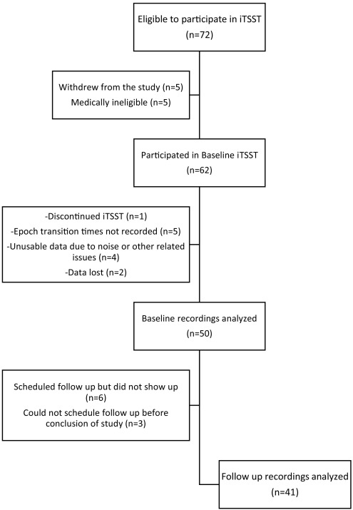

Fig. 1. Flowchart of participants in the pilot [iTSST](https://www-sciencedirect-com.proxy.lib.duke.edu/topics/neuroscience/trier-social-stress-test) study.

### 4.2. Change in self-reported mood in response to the iTSST

There was a significant main effect of Phase on self-reports of relaxation, *F* (1, 40) = 79.05, *SE* = 0.33, *p* < .01, η<sub>p</sub><sup>2</sup> = 0.80. Participants reported a significant reduction in self-reported relaxation from resting (*M* = 3.29, *SE* = 0.09) to speech/mental arithmetic (*M* = 2.48, *SE* = 0.08), *M*<sub>*Diff*</sub> = 0.81, *SE* = 0.11, *p* < .01, followed by an increase during recovery (*M* = 3.27, *SE* = 0.07), *M*<sub>*Diff*</sub> = 0.79, *SE* = 0.6, *p* < .01, when averaged across the two iTSST administration sessions. Self-report of relaxation did not differ between baseline and recovery, *M*<sub>*Diff*</sub> = 0.02, *SE* = 0.09, *p* = .82. There was a main effect of Time on self-reported relaxation, *F* (1, 41) = 6.21, *SE* = 0.44, *p* = .02, η<sub>p</sub><sup>2</sup> = 0.13, with lower self-reports of relaxation during the initial iTSST administration, (*M* = 2.91, *SE* = 0.08), relative to the second administration, (*M* = 3.12, *SE* = 0.08). There was no Time by Phase interaction, *p* = .06, η<sub>p</sub><sup>2</sup> = 0.13.

#### 4.2.1. Change in heart rate in response to the iTSST

There was a significant main effect of Phase on heart rate, *F* (1, 39) = 37.03, *SE* = 19.31, *p* < .01, η<sub>p</sub><sup>2</sup> = 0.66. A significant increase in heart rate was observed from resting (*M* = 71.81 bpm, *SE* = 1.22) to speech/mental arithmetic (*M* = 77.16 bpm, *SE* = 1.34), *M*<sub>*Diff*</sub> = 5.36 bpm, *SE* = 0.72, *p* < .01, followed by a decrease during recovery (*M* = 70.42 bpm, *SE* = 1.14), *M*<sub>*Diff*</sub> = 6.74 bpm, *SE* = 0.78, *p* < .01, when averaged across the two iTSST administration sessions. Heart rate was significantly lower at recovery than baseline, *M*<sub>*Diff*</sub> = 1.39 bpm, *SE* = 0.53, *p* = .01. There was no main effect of Time, *p* = .36, η<sub>p</sub><sup>2</sup> = 0.02, or Time by Phase interaction, *p* = .99, η<sub>p</sub><sup>2</sup> = 0.00.

#### 4.2.2. Change in RMSSD in response to the iTSST

There was a significant main effect of Phase on RMSSD, *F* (1, 39) = 11.41, *SE* = 174.91, *p* < .01, η<sub>p</sub><sup>2</sup> = 0.38. A significant reduction in RMSSD was observed from resting (*M* = 44.81, *SE* = 9.15) to speech/mental arithmetic (*M* = 37.05, *SE* = 7.09), *M*<sub>*Diff*</sub> = 7.76, *SE* = 2.64, *p* < .01 followed by an increase during recovery (*M* = 45.43, *SE* = 0.8.44), *M*<sub>*Diff*</sub> = 8.38, *SE* = 1.77, *p* < .01, when averaged across the two iTSST administration sessions. RMSSD did not differ between baseline and recovery, *M*<sub>*Diff*</sub> = 0.61, *SE* = 1.73, *p* = .73. There was no main effect of Time, *p* = .90, η<sub>p</sub><sup>2</sup> = 0.00, or Time by Phase interaction, *p* = .50, η<sub>p</sub><sup>2</sup> = 0.03.

#### 4.2.3. Percentage change in RMSSD in response to the iTSST

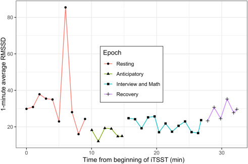

Fig. 2. One-minute average RMSSD values during the [iTSST](https://www-sciencedirect-com.proxy.lib.duke.edu/topics/neuroscience/trier-social-stress-test) for one representative participant.

In Fig. 3, we present a histogram of the percent change in RMSSD from resting to the lowest value observed in the speech/arithmetic of the iTSST. As this figure shows, 2 participants showed an increase in RMSSD, and one participant had a less than 10% change in RMSSD. The rest of the observations (94%), showed between a 10% to 100% decrease in RMSSD from resting during the speech/arithmetic phase of the iTSST. The average percentage change from resting to speech/arithmetic was 44.8% (sd = 23.2%). In supplemental analyses that are not shown, we examined if any control variables (female gender, White, age, BMI and Godin score) were correlated with percent change in RMSSD during the initial iTSST administration. None of the control variables were correlated with percentage change from resting to speech/arithmetic phase.

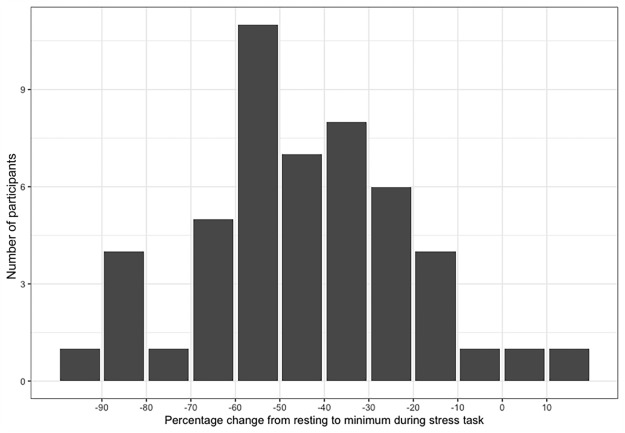

#### 4.2.4. Repeatability

The observed percentage change from resting to speech/arithmetic during the second iTSST administration was similar to the first administration with a mean percentage change of 46.2% (*SD* = 19.7%). Only one participant had a positive change during the second iTSST administration and the rest exhibited greater than a 10% reduction in RMSSD.

## 5. Discussion

The modification of the TSST to be delivered remotely has several clear advantages to laboratory-based administration, including reduced participant demand, cost-efficiency, ease of scheduling, ecological validity, and ability to accommodate unforeseen circumstances such as social distancing in response to COVID-19. Despite clear advantages, a number of challenges arose during the adaptation of the iTSST, which highlighted avenues for improving future iTSST administration. Technology presented as a potential barrier. For example, some participants had difficulty orienting to the webcam and those connecting from rural locations sometimes experienced difficulty in audio and video stability which could impact the effectiveness of the iTSST. Further, although we asked participants to turn off notifications and be free from distraction, some participants experienced interruptions during session (e.g., text messages, small children or pets). Furthermore, participants occasionally moved during session (e.g., to find a stronger internet signal) which could introduce movement artifact into cardiovascular recording. Finally, speeches were delivered seated because standing removed their face from the camera view.

The clinical implications of the observed results are not yet known. While observational studies have observed associations between magnitude of cardiovascular responses to acute psychological stress tasks and the development of hypertension (Carroll et al., 2001, Carroll et al., 2003), coronary artery calcification (Matthews et al., 2006), and acute cardiovascular events (Carroll et al., 2012a), these studies have typically measured response of the [sympathetic nervous system](https://www-sciencedirect-com.proxy.lib.duke.edu/topics/neuroscience/sympathetic-nervous-system) *and* the hypothalamic-pituitary-adrenal (HPA) axis. Fortunately, the cohort evaluated in the present investigation is well characterized with more than a decade of longitudinal research (Blouin and Proeschold-Bell, 2015; cf. Milstein et al., 2019; Proeschold-Bell et al., 2013) and future assessments will provide an answer to this question.

### 5.1. Limitations

There are several limitations that must be considered when interpreting results of this study. First, only one biological marker of stress was included in the present investigation (i.e., cardiovascular reactivity). Research protocols involving the TSST typically acquire saliva and blood to derive markers of activation of the HPA-axis, and immune system function (refer to Allen et al., 2014, Allen et al., 2016 for reviews). Similarly, the present study utilized an index of [parasympathetic nervous system](https://www-sciencedirect-com.proxy.lib.duke.edu/topics/psychology/parasympathetic-nervous-system) activation in RMSSD, but did not employ a marker of sympathetic arousal (e.g., pre-ejection period or α-amylase). The iTSST resulted in a reliable increase in HR, which cannot conclusively suggest an increase in sympathetic arousal due to change in HR being multiply determined by sympathetic and parasympathetic influences. As such, claims can only be made about one facet of a coordinated [stress response system](https://www-sciencedirect-com.proxy.lib.duke.edu/topics/psychology/stress-response-system), though it is encouraging that parasympathetic activation during stress tends to be reciprocally related to sympathetic (Berntson et al., 1991), and HPA-axis responses (Doussard-Roosevelt et al., 2003). Finally, change in respiration rate can confound change in parasympathetic cardiac control (Grossman and Taylor, 2007) and respiration was not measured nor statistically adjusted for. This concern is somewhat tempered given that RMSSD is less affected by changes in rate and volume of respiration than frequency-domain measures (Penttilä et al., 2001).

## Funder source

This project was funded by a grant from the Rural Church area of The Duke Endowment.

## Appendix A. Supplementary data

[Download : Download Word document (25KB)](https://ars-els-cdn-com.proxy.lib.duke.edu/content/image/1-s2.0-S0167876021001318-mmc1.docx)

Descriptions of the Four Selah Pilot Study Interventions.

## References

**Allen et al., 2014**

A.P. Allen, P.J. Kennedy, J.F. Cryan, T.G. Dinan, G. Clarke

**Biological and psychological markers of stress in humans: focus on the Trier Social Stress Test**

Neurosci. Biobehav. Rev., 38 (2014), pp. 94-124

(doi:10/f5ts45)

[Article](https://www-sciencedirect-com.proxy.lib.duke.edu/science/article/pii/S0149763413002728)[Download PDF](https://www-sciencedirect-com.proxy.lib.duke.edu/science/article/pii/S0149763413002728/pdfft?md5=360872895564ff769d301606b0b7f6f9&pid=1-s2.0-S0149763413002728-main.pdf)[View Record in Scopus](https://www.scopus.com/inward/record.url?eid=2-s2.0-84890080017&partnerID=10&rel=R3.0.0)Google Scholar

**Allen et al., 2016**

A.P. Allen, P.J. Kennedy, S. Dockray, J.F. Cryan, T.G. Dinan, G. Clarke

**The Trier Social Stress Test: principles and practice**

Neurobiology of Stress, 6 (2016), pp. 113-126

(doi:10/gfc4vv)

[CrossRef](https://doi.org/10.5688/ajpe807113)[View Record in Scopus](https://www.scopus.com/inward/record.url?eid=2-s2.0-84991463657&partnerID=10&rel=R3.0.0)Google Scholar

**Bergmann et al., 2014**

N. Bergmann, F. Gyntelberg, J. Faber

**The appraisal of chronic stress and the development of the metabolic syndrome: a systematic review of prospective cohort studies**

Endocrine Connections, 3 (2) (2014), pp. R55-R80, 10.1530/EC-14-0031

[View Record in Scopus](https://www.scopus.com/inward/record.url?eid=2-s2.0-84918583737&partnerID=10&rel=R3.0.0)Google Scholar

**Berntson et al., 1990**

G.G. Berntson, K.S. Quigley, J.F. Jang, S.T. Boysen

**An approach to artifact identification: application to heart period data**

Psychophysiology, 27 (5) (1990), pp. 586-598, 10.1111/j.1469-8986.1990.tb01982.x

[CrossRef](https://doi.org/10.1111/j.1469-8986.1990.tb01982.x)[View Record in Scopus](https://www.scopus.com/inward/record.url?eid=2-s2.0-0025225356&partnerID=10&rel=R3.0.0)Google Scholar

**Berntson et al., 1991**

G.G. Berntson, J.T. Cacioppo, K.S. Quigley

**Autonomic determinism: the modes of autonomic control, the doctrine of autonomic space, and the laws of autonomic constraint**

Psychol. Rev., 98 (4) (1991), pp. 459-487, 10.1037/0033-295x.98.4.459

[View Record in Scopus](https://www.scopus.com/inward/record.url?eid=2-s2.0-0026234527&partnerID=10&rel=R3.0.0)Google Scholar

**Berntson et al., 1997**

G.G. Berntson, J. Bigger, D. Eckberg, P. Grossman, P. Kaufmann, M. Malik, H. Nagaraja, S. Porges, P. Saul, P. Stone, M. van der Molen

**Heart rate variability: origins, methods, and interpretive caveats**

Psychophysiology, 34 (1997), pp. 623-648, 10.1111/j.1469-8986.1997.tb02140.x

[CrossRef](https://doi.org/10.1111/j.1469-8986.1997.tb02140.x)[View Record in Scopus](https://www.scopus.com/inward/record.url?eid=2-s2.0-0343416365&partnerID=10&rel=R3.0.0)Google Scholar

**Blouin and Proeschold-Bell, 2015**

R. Blouin, R.J. Proeschold-Bell

**Measuring stress in a clergy population: lessons learned from cognitive interview testing of the perceived stress scale with clergy**

A. Village, R. Hood (Eds.), Research in the Social Scientific Study of Religion, Brill (2015), pp. 141-154, 10.1163/9789004299436_010

[View Record in Scopus](https://www.scopus.com/inward/record.url?eid=2-s2.0-85030704142&partnerID=10&rel=R3.0.0)Google Scholar

**Brown and Bauman, 2000**

W.J. Brown, A.E. Bauman

**Comparison of estimates of population levels of physical activity using two measures**

Aust. N. Z. J. Public Health, 24 (5) (2000), pp. 520-525, 10.1111/j.1467-842x.2000.tb00503.x

[CrossRef](https://doi.org/10.1111/j.1467-842X.2000.tb00503.x)[View Record in Scopus](https://www.scopus.com/inward/record.url?eid=2-s2.0-0033708939&partnerID=10&rel=R3.0.0)Google Scholar

**Carroll et al., 2001**

D. Carroll, G.D. Smith, M.J. Shipley, A. Steptoe, E.J. Brunner, M.G. Marmot

**Blood pressure reactions to acute psychological stress and future blood pressure status: a 10-year follow-up of men in the Whitehall II study**

Psychosom. Med., 63 (5) (2001), pp. 737-743, 10.1097/00006842-200109000-00006

[CrossRef](https://doi.org/10.1097/00006842-200109000-00006)[View Record in Scopus](https://www.scopus.com/inward/record.url?eid=2-s2.0-0034801810&partnerID=10&rel=R3.0.0)Google Scholar

**Carroll et al., 2003**

D. Carroll, C. Ring, K. Hunt, G. Ford, S. Macintyre

**Blood pressure reactions to stress and the prediction of future blood pressure: effects of sex, age, and socioeconomic position**

Psychosom. Med., 65 (6) (2003), pp. 1058-1064, 10.1097/01.psy.0000097330.58739.26

[View Record in Scopus](https://www.scopus.com/inward/record.url?eid=2-s2.0-0347986760&partnerID=10&rel=R3.0.0)Google Scholar

**Carroll et al., 2012a**

D. Carroll, A.T. Ginty, G. Der, K. Hunt, M. Benzeval, A.C. Phillips

**Increased blood pressure reactions to acute mental stress are associated with 16-year cardiovascular disease mortality**

Psychophysiology, 49 (10) (2012), pp. 1444-1448, 10.1111/j.1469-8986.2012.01463.x

[CrossRef](https://doi.org/10.1111/j.1469-8986.2012.01463.x)[View Record in Scopus](https://www.scopus.com/inward/record.url?eid=2-s2.0-84866352279&partnerID=10&rel=R3.0.0)Google Scholar

**Carroll et al., 2012b**

D. Carroll, A.C. Phillips, W.R. Lovallo

**The behavioral and health corollaries of blunted physiological reactions to acute psychological stress: revising the reactivity hypothesis**

How Motivation Affects Cardiovascular Response: Mechanisms and Applications, American Psychological Association (2012), pp. 243-263, 10.1037/13090-012

[CrossRef](https://doi.org/10.1037/13090-012)Google Scholar

**de Rooij, 2013**

S.R. de Rooij

**Blunted cardiovascular and cortisol reactivity to acute psychological stress: a summary of results from the Dutch Famine Birth Cohort Study**

International Journal of Psychophysiology: Official Journal of the International Organization of Psychophysiology, 90 (1) (2013), pp. 21-27, 10.1016/j.ijpsycho.2012.09.011

[Article](https://www-sciencedirect-com.proxy.lib.duke.edu/science/article/pii/S0167876012006101)[Download PDF](https://www-sciencedirect-com.proxy.lib.duke.edu/science/article/pii/S0167876012006101/pdfft?md5=a25b89b3e1f4e5d3f301b483424a2128&pid=1-s2.0-S0167876012006101-main.pdf)[View Record in Scopus](https://www.scopus.com/inward/record.url?eid=2-s2.0-84886430728&partnerID=10&rel=R3.0.0)Google Scholar

**Doussard-Roosevelt et al., 2003**

J.A. Doussard-Roosevelt, L.A. Montgomery, S.W. Porges

**Short-term stability of physiological measures in kindergarten children: respiratory sinus arrhythmia, heart period, and cortisol**

Dev. Psychobiol., 43 (3) (2003), pp. 230-242, 10.1002/dev.10136

[View Record in Scopus](https://www.scopus.com/inward/record.url?eid=2-s2.0-0141992934&partnerID=10&rel=R3.0.0)Google Scholar

**Fredrikson et al., 1989**

M. Fredrikson, J.A. Blumenthal, D.D. Evans, A. Sherwood, K.C. Light

**Cardiovascular responses in the laboratory and in the natural environment: is blood pressure reactivity to laboratory-induced mental stress related to ambulatory blood pressure during everyday life?**

J. Psychosom. Res., 33 (6) (1989), pp. 753-762, 10.1016/0022-3999(89)90091-3

[Article](https://www-sciencedirect-com.proxy.lib.duke.edu/science/article/pii/0022399989900913)[Download PDF](https://www-sciencedirect-com.proxy.lib.duke.edu/science/article/pii/0022399989900913/pdf?md5=7f98b05fced71c3aeab9522dc7ea077d&pid=1-s2.0-0022399989900913-main.pdf)[View Record in Scopus](https://www.scopus.com/inward/record.url?eid=2-s2.0-0024851266&partnerID=10&rel=R3.0.0)Google Scholar

**Gerra et al., 2001**

G. Gerra, A. Zaimovic, G.G. Mascetti, S. Gardini, U. Zambelli, M. Timpano, M.A. Raggi, F. Brambilla

**Neuroendocrine responses to experimentally-induced psychological stress in healthy humans**

Psychoneuroendocrinology, 26 (1) (2001), pp. 91-107, 10.1016/s0306-4530(00)00046-9

[Article](https://www-sciencedirect-com.proxy.lib.duke.edu/science/article/pii/S0306453000000469)[Download PDF](https://www-sciencedirect-com.proxy.lib.duke.edu/science/article/pii/S0306453000000469/pdfft?md5=e31cb2c3c6ae342f8d11c24966c4fe86&pid=1-s2.0-S0306453000000469-main.pdf)[View Record in Scopus](https://www.scopus.com/inward/record.url?eid=2-s2.0-0035219255&partnerID=10&rel=R3.0.0)Google Scholar

**Giese-Davis et al., 2006**

J. Giese-Davis, F.H. Wilhelm, A. Conrad, H.C. Abercrombie, S. Sephton, M. Yutsis, E. Neri, C.B. Taylor, H.C. Kraemer, D. Spiegel

**Depression and stress reactivity in metastatic breast cancer**

Psychosom. Med., 68 (5) (2006), pp. 675-683, 10.1097/01.psy.0000238216.88515.e5

[CrossRef](https://doi.org/10.1097/01.psy.0000238216.88515.e5)[View Record in Scopus](https://www.scopus.com/inward/record.url?eid=2-s2.0-33749008197&partnerID=10&rel=R3.0.0)Google Scholar

**Godin, 2011**

G. Godin

**The Godin-Shephard leisure-time physical activity questionnaire**

The Health & Fitness Journal of Canada, 4 (1) (2011), pp. 18-22, 10.14288/hfjc.v4i1.82

[View Record in Scopus](https://www.scopus.com/inward/record.url?eid=2-s2.0-84862194734&partnerID=10&rel=R3.0.0)[Google Scholar](https://scholar.google.com/scholar_lookup?title=The%20Godin-Shephard%20leisure-time%20physical%20activity%20questionnaire&publication_year=2011&author=G.%20Godin)

**Grossman and Taylor, 2007**

P. Grossman, E.W. Taylor

**Toward understanding respiratory sinus arrhythmia: relations to cardiac vagal tone, evolution and biobehavioral functions**

Biol. Psychol., 74 (2) (2007), pp. 263-285, 10.1016/j.biopsycho.2005.11.014

[Article](https://www-sciencedirect-com.proxy.lib.duke.edu/science/article/pii/S0301051106001876)[Download PDF](https://www-sciencedirect-com.proxy.lib.duke.edu/science/article/pii/S0301051106001876/pdfft?md5=f92af00437ec5a3f193104a5453344eb&pid=1-s2.0-S0301051106001876-main.pdf)[View Record in Scopus](https://www.scopus.com/inward/record.url?eid=2-s2.0-33845700509&partnerID=10&rel=R3.0.0)Google Scholar

**Hawn et al., 2015**

S.E. Hawn, L. Paul, S. Thomas, S. Miller, A.B. Amstadter

**Stress reactivity to an electronic version of the Trier Social Stress Test: a pilot study**

Front. Psychol., 6 (2015), 10.3389/fpsyg.2015.00724

Google Scholar

**Hellhammer and Schubert, 2012**

J. Hellhammer, M. Schubert

**The physiological response to Trier Social Stress Test relates to subjective measures of stress during but not before or after the test**

Psychoneuroendocrinology, 37 (1) (2012), pp. 119-124, 10.1016/j.psyneuen.2011.05.012

[Article](https://www-sciencedirect-com.proxy.lib.duke.edu/science/article/pii/S030645301100165X)[Download PDF](https://www-sciencedirect-com.proxy.lib.duke.edu/science/article/pii/S030645301100165X/pdfft?md5=fa2f599cc51db076b13bfd4328479bf7&pid=1-s2.0-S030645301100165X-main.pdf)[View Record in Scopus](https://www.scopus.com/inward/record.url?eid=2-s2.0-83055194689&partnerID=10&rel=R3.0.0)Google Scholar

**Jacobs et al., 1993**

D.R. Jacobs, B.E. Ainsworth, T.J. Hartman, A.S. Leon

**A simultaneous evaluation of 10 commonly used physical activity questionnaires**

Med. Sci. Sports Exerc., 25 (1) (1993), pp. 81-91, 10.1249/00005768-199301000-00012

[CrossRef](https://doi.org/10.1249/00005768-199301000-00012)[View Record in Scopus](https://www.scopus.com/inward/record.url?eid=2-s2.0-0027529922&partnerID=10&rel=R3.0.0)Google Scholar

**Jönsson et al., 2010**

P. Jönsson, M. Wallergård, K. Österberg, Å.M. Hansen, G. Johansson, B. Karlson

**Cardiovascular and cortisol reactivity and habituation to a virtual reality version of the Trier Social Stress Test: a pilot study**

Psychoneuroendocrinology, 35 (9) (2010), pp. 1397-1403, 10.1016/j.psyneuen.2010.04.003

[Article](https://www-sciencedirect-com.proxy.lib.duke.edu/science/article/pii/S0306453010000934)[Download PDF](https://www-sciencedirect-com.proxy.lib.duke.edu/science/article/pii/S0306453010000934/pdfft?md5=5cef91f52c0bc0d2681233a8acdf5b0b&pid=1-s2.0-S0306453010000934-main.pdf)[View Record in Scopus](https://www.scopus.com/inward/record.url?eid=2-s2.0-77956618793&partnerID=10&rel=R3.0.0)Google Scholar

**Kelly et al., 2007**

O. Kelly, K. Matheson, A. Martinez, Z. Merali, H. Anisman

**Psychosocial stress evoked by a virtual audience: relation to neuroendocrine activity**

Cyberpsychology & Behavior: The Impact of the Internet, Multimedia and Virtual Reality on Behavior and Society, 10 (5) (2007), pp. 655-662, 10.1089/cpb.2007.9973

[CrossRef](https://doi.org/10.1089/cpb.2007.9973)[View Record in Scopus](https://www.scopus.com/inward/record.url?eid=2-s2.0-35348922478&partnerID=10&rel=R3.0.0)Google Scholar

**Kim et al., 2018**

H.-G. Kim, E.-J. Cheon, D.-S. Bai, Y.H. Lee, B.-H. Koo

**Stress and heart rate variability: a meta-analysis and review of the literature**

Psychiatry Investig., 15 (3) (2018), pp. 235-245

(doi:10/gc3zg8)

[View Record in Scopus](https://www.scopus.com/inward/record.url?eid=2-s2.0-85045400208&partnerID=10&rel=R3.0.0)Google Scholar

**Kirschbaum et al., 1993**

C. Kirschbaum, K.M. Pirke, D.H. Hellhammer

**The ‘Trier Social Stress Test’—a tool for investigating psychobiological stress responses in a laboratory setting**

Neuropsychobiology, 28 (1–2) (1993), pp. 76-81, 10.1159/000119004

[CrossRef](https://doi.org/10.1159/000119004)[View Record in Scopus](https://www.scopus.com/inward/record.url?eid=2-s2.0-0027517172&partnerID=10&rel=R3.0.0)[Google Scholar](https://scholar.google.com/scholar?q=The%20Trier%20Social%20Stress%20Testa%20tool%20for%20investigating%20psychobiological%20stress%20responses%20in%20a%20laboratory%20setting)

**Kotlyar et al., 2008**

M. Kotlyar, C. Donahue, P. Thuras, M.G. Kushner, N. O’Gorman, E.A. Smith, D.E. Adson

**Physiological response to a speech stressor presented in a virtual reality environment**

Psychophysiology, 45 (6) (2008), pp. 1034-1037

(doi:10/cq6bbg)

[CrossRef](https://doi.org/10.1111/j.1469-8986.2008.00690.x)[View Record in Scopus](https://www.scopus.com/inward/record.url?eid=2-s2.0-54049094858&partnerID=10&rel=R3.0.0)Google Scholar

**Kudielka et al., 2007**

B.M. Kudielka, D.H. Hellhammer, C. Kirschbaum

**Ten years of research with the Trier Social Stress Test—revisited**

Social Neuroscience: Integrating Biological and Psychological Explanations of Social Behavior, The Guilford Press (2007), pp. 56-83

[View Record in Scopus](https://www.scopus.com/inward/record.url?eid=2-s2.0-85034700490&partnerID=10&rel=R3.0.0)[Google Scholar](https://scholar.google.com/scholar?q=Ten%20years%20of%20research%20with%20the%20Trier%20Social%20Stress%20Testrevisited)

**Lackschewitz et al., 2008**

H. Lackschewitz, G. Hüther, B. Kröner-Herwig

**Physiological and psychological stress responses in adults with attention-deficit/hyperactivity disorder (ADHD)**

Psychoneuroendocrinology, 33 (5) (2008), pp. 612-624, 10.1016/j.psyneuen.2008.01.016

[Article](https://www-sciencedirect-com.proxy.lib.duke.edu/science/article/pii/S0306453008000401)[Download PDF](https://www-sciencedirect-com.proxy.lib.duke.edu/science/article/pii/S0306453008000401/pdfft?md5=68e7dec3fc7b9ee593eaf371902edeb4&pid=1-s2.0-S0306453008000401-main.pdf)[View Record in Scopus](https://www.scopus.com/inward/record.url?eid=2-s2.0-42749095865&partnerID=10&rel=R3.0.0)[Google Scholar](https://scholar.google.com/scholar?q=Physiological%20and%20psychological%20stress%20responses%20in%20adults%20with%20attention-deficithyperactivity%20disorder)

**Lutgendorf and Andersen, 2015**

S.K. Lutgendorf, B.L. Andersen

**Biobehavioral approaches to cancer progression and survival: mechanisms and interventions**

The American Psychologist, 70 (2) (2015), pp. 186-197, 10.1037/a0035730

[CrossRef](https://doi.org/10.1037/a0035730)[View Record in Scopus](https://www.scopus.com/inward/record.url?eid=2-s2.0-84925603983&partnerID=10&rel=R3.0.0)Google Scholar

**Matthews et al., 2006**

K.A. Matthews, S. Zhu, D.C. Tucker, M.A. Whooley

**Blood pressure reactivity to psychological stress and coronary calcification in the Coronary Artery Risk Development in Young Adults Study**

Hypertension (Dallas, Tex.: 1979), 47 (3) (2006), pp. 391-395, 10.1161/01.HYP.0000200713.44895.38

[View Record in Scopus](https://www.scopus.com/inward/record.url?eid=2-s2.0-33644986917&partnerID=10&rel=R3.0.0)Google Scholar

**Milstein et al., 2019**

G. Milstein, C.F. Hybels, R.J. Proeschold-Bell

**A prospective study of clergy spiritual well-being, depressive symptoms, and occupational distress**

Psychol. Relig. Spiritual. (2019), 10.1037/rel0000252

Google Scholar

**Minarini, 2020**

G. Minarini

**Root mean square of the successive differences as marker of the parasympathetic system and difference in the outcome after ANS stimulation**

Autonomic Nervous System Monitoring - Heart Rate Variability (2020), 10.5772/intechopen.89827

Google Scholar

**Mischler et al., 2005**

K. Mischler, J.E. Fischer, L. Zgraggen, B.M. Kudielka, D. Preckel, R. von Känel

**The effect of repeated acute mental stress on habituation and recovery responses in hemoconcentration and blood cells in healthy men**

Life Sci., 77 (10) (2005), pp. 1166-1179, 10.1016/j.lfs.2005.03.006

[Article](https://www-sciencedirect-com.proxy.lib.duke.edu/science/article/pii/S0024320505003292)[Download PDF](https://www-sciencedirect-com.proxy.lib.duke.edu/science/article/pii/S0024320505003292/pdfft?md5=e415c54b2fed5c9e1e0847a4a9a25f1e&pid=1-s2.0-S0024320505003292-main.pdf)[View Record in Scopus](https://www.scopus.com/inward/record.url?eid=2-s2.0-20644456888&partnerID=10&rel=R3.0.0)Google Scholar

**Monfredi et al., 2014**

O. Monfredi, A.E. Lyashkov, A.-B. Johnsen, S. Inada, H. Schneider, R. Wang, M. Nirmalan, U. Wisloff, V.A. Maltsev, E.G. Lakatta, H. Zhang, M.R. Boyett

**Biophysical characterization of the underappreciated and important relationship between heart rate variability and heart rate**

Hypertension, 64 (6) (2014), pp. 1334-1343, 10.1161/HYPERTENSIONAHA.114.03782

[View Record in Scopus](https://www.scopus.com/inward/record.url?eid=2-s2.0-84922480332&partnerID=10&rel=R3.0.0)Google Scholar

**Montero-López et al., 2016**

E. Montero-López, A. Santos-Ruiz, M.C. García-Ríos, R. Rodríguez-Blázquez, M. Pérez-García, M.I. Peralta-Ramírez

**A virtual reality approach to the Trier Social Stress Test: contrasting two distinct protocols**

Behav. Res. Methods, 48 (1) (2016), pp. 223-232, 10.3758/s13428-015-0565-4

[CrossRef](https://doi.org/10.3758/s13428-015-0565-4)[View Record in Scopus](https://www.scopus.com/inward/record.url?eid=2-s2.0-84922736861&partnerID=10&rel=R3.0.0)Google Scholar

**Obrist, 1981**

P.A. Obrist

**Cardiovascular Psychophysiology: A Perspective**

Springer US (1981), 10.1007/978-1-4684-8491-5

[Google Scholar](https://scholar.google.com/scholar_lookup?title=Cardiovascular%20Psychophysiology%3A%20A%20Perspective&publication_year=1981&author=P.A.%20Obrist)

**Penttilä et al., 2001**

J. Penttilä, A. Helminen, T. Jartti, T. Kuusela, H.V. Huikuri, M.P. Tulppo, R. Coffeng, H. Scheinin

**Time domain, geometrical and frequency domain analysis of cardiac vagal outflow: effects of various respiratory patterns**

Clin. Physiol., 21 (3) (2001), pp. 365-376, 10.1046/j.1365-2281.2001.00337.x

[View Record in Scopus](https://www.scopus.com/inward/record.url?eid=2-s2.0-0035012677&partnerID=10&rel=R3.0.0)Google Scholar

**Proeschold-Bell et al., 2013**

R.J. Proeschold-Bell, A. Miles, M. Toth, C. Adams, B.W. Smith, D. Toole

**Using effort-reward imbalance theory to understand high rates of depression and anxiety among clergy**

J. Prim. Prev., 34 (6) (2013), pp. 439-453, 10.1007/s10935-013-0321-4

[CrossRef](https://doi.org/10.1007/s10935-013-0321-4)[View Record in Scopus](https://www.scopus.com/inward/record.url?eid=2-s2.0-84893753318&partnerID=10&rel=R3.0.0)Google Scholar

**Quintana and Heathers, 2014**

D.S. Quintana, J.A.J. Heathers

**Considerations in the assessment of heart rate variability in biobehavioral research**

Front. Psychol. (2014), p. 5

(doi:10/f6bwt5)

Google Scholar

**Rohleder et al., 2006**

N. Rohleder, J.M. Wolf, E.F. Maldonado, C. Kirschbaum

**The psychosocial stress-induced increase in salivary alpha-amylase is independent of saliva flow rate**

Psychophysiology, 43 (6) (2006), pp. 645-652, 10.1111/j.1469-8986.2006.00457.x

[CrossRef](https://doi.org/10.1111/j.1469-8986.2006.00457.x)[View Record in Scopus](https://www.scopus.com/inward/record.url?eid=2-s2.0-33750452730&partnerID=10&rel=R3.0.0)Google Scholar

**Schommer et al., 2003**

N.C. Schommer, D.H. Hellhammer, C. Kirschbaum

**Dissociation between reactivity of the hypothalamus-pituitary-adrenal axis and the sympathetic-adrenal-medullary system to repeated psychosocial stress**

Psychosom. Med., 65 (3) (2003), pp. 450-460, 10.1097/01.psy.0000035721.12441.17

[View Record in Scopus](https://www.scopus.com/inward/record.url?eid=2-s2.0-0012798610&partnerID=10&rel=R3.0.0)Google Scholar

**Shiban et al., 2016**

Y. Shiban, J. Diemer, S. Brandl, R. Zack, A. Mühlberger, S. Wüst

**Trier Social Stress Test in vivo and in virtual reality: dissociation of response domains**

International Journal of Psychophysiology: Official Journal of the International Organization of Psychophysiology, 110 (2016), pp. 47-55, 10.1016/j.ijpsycho.2016.10.008

[Article](https://www-sciencedirect-com.proxy.lib.duke.edu/science/article/pii/S0167876016307231)[Download PDF](https://www-sciencedirect-com.proxy.lib.duke.edu/science/article/pii/S0167876016307231/pdfft?md5=4ff01e7c24509d8fd37d9c91f9aaebd6&pid=1-s2.0-S0167876016307231-main.pdf)[View Record in Scopus](https://www.scopus.com/inward/record.url?eid=2-s2.0-84992336056&partnerID=10&rel=R3.0.0)Google Scholar

**Steptoe and Kivimäki, 2013**

A. Steptoe, M. Kivimäki

**Stress and cardiovascular disease: an update on current knowledge**

Annu. Rev. Public Health, 34 (2013), pp. 337-354, 10.1146/annurev-publhealth-031912-114452

[CrossRef](https://doi.org/10.1146/annurev-publhealth-031912-114452)[View Record in Scopus](https://www.scopus.com/inward/record.url?eid=2-s2.0-84875428130&partnerID=10&rel=R3.0.0)[Google Scholar](https://scholar.google.com/scholar_lookup?title=Stress%20and%20cardiovascular%20disease%3A%20an%20update%20on%20current%20knowledge&publication_year=2013&author=A.%20Steptoe&author=M.%20Kivim%C3%A4ki)

**von Känel et al., 2006**

R. von Känel, B.M. Kudielka, D. Preckel, D. Hanebuth, J.E. Fischer

**Delayed response and lack of habituation in plasma interleukin-6 to acute mental stress in men**

Brain Behav. Immun., 20 (1) (2006), pp. 40-48, 10.1016/j.bbi.2005.03.013

[Article](https://www-sciencedirect-com.proxy.lib.duke.edu/science/article/pii/S0889159105000644)[Download PDF](https://www-sciencedirect-com.proxy.lib.duke.edu/science/article/pii/S0889159105000644/pdfft?md5=0117eb03b1bb683913f566cf67c5f529&pid=1-s2.0-S0889159105000644-main.pdf)[View Record in Scopus](https://www.scopus.com/inward/record.url?eid=2-s2.0-29144515548&partnerID=10&rel=R3.0.0)Google Scholar

**Way and Taylor, 2011**

B.M. Way, S.E. Taylor

**A polymorphism in the serotonin transporter gene moderates cardiovascular reactivity to psychosocial stress**

Psychosom. Med., 73 (4) (2011), pp. 310-317, 10.1097/PSY.0b013e31821195ed

[View Record in Scopus](https://www.scopus.com/inward/record.url?eid=2-s2.0-79955831452&partnerID=10&rel=R3.0.0)Google Scholar

**Yim et al., 2015**

I.S. Yim, J.A. Quas, E.B. Rush, D.A. Granger, N. Skoluda

**Experimental manipulation of the Trier Social Stress Test-Modified (TSST-M) to vary arousal across development**

Psychoneuroendocrinology, 57 (2015), pp. 61-71, 10.1016/j.psyneuen.2015.03.021

[Article](https://www-sciencedirect-com.proxy.lib.duke.edu/science/article/pii/S0306453015001250)[Download PDF](https://www-sciencedirect-com.proxy.lib.duke.edu/science/article/pii/S0306453015001250/pdfft?md5=d26e3c1d33b0f2dd2d5c3ea1973d4991&pid=1-s2.0-S0306453015001250-main.pdf)[View Record in Scopus](https://www.scopus.com/inward/record.url?eid=2-s2.0-84929377998&partnerID=10&rel=R3.0.0)[Google Scholar](https://scholar.google.com/scholar?q=Experimental%20manipulation%20of%20the%20Trier%20Social%20Stress%20Test-Modified%20%20to%20vary%20arousal%20across%20development)

**<sup>1</sup>**

Connotes equal author contribution.

[View Abstract](https://www-sciencedirect-com.proxy.lib.duke.edu/science/article/abs/pii/S0167876021001318)

© 2021 Elsevier B.V. All rights reserved.

12

## Citing articles (0)